# Legal hypergraphs on toy data: the whole workflow, step by step

honets

2026-09-07

> This is the legal-hypergraphs workflow (Coupette, Hartung and Katz 2024) on data small enough to read by eye. Every step is one call. The real analysis, on the authors’ released data, is `legal-hypergraphs.html`; the verbs are the same, only the data change.

## The two kinds of data

The paper uses two datasets. **Tribunals**: a case is decided by three arbitrators, from the day the tribunal is constituted to the day the case concludes. The three arbitrators are bound together for that interval. **Citations**: a decision cites earlier decisions in blocks. The decisions cited together in one block are bound together on the day of the citing decision.

We make both up with base R. A seed makes the data the same every time.

```r
set.seed(2024)
```

### Fake tribunals

Twenty arbitrators and forty cases. Every case has three seats. A few arbitrators are much busier than the rest, as in the real data, so some pairs and even trios sit together more than once.

```r
arbitrators <- sprintf("arbitrator_%02d", 1:20)
```

```r
cases <- sprintf("case_%02d", 1:40)
```

```r
seats <- unlist(lapply(cases, function(case) {
  sample(arbitrators, size = 3, prob = 1 / seq_along(arbitrators))
}))
```

Each case is constituted on a random day between 2010 and 2019 and concludes one to four years later. Eight cases are still pending, so their conclusion date is missing.

```r
constituted <- as.Date("2010-01-01") + sort(sample(0:3650, size = 40))
concluded <- constituted + sample(365:1460, size = 40)
concluded[33:40] <- NA
```

Each case belongs to an economic sector, a property of the case, not of a seat.

```r
sector <- sample(c("energy", "mining", "finance", "construction"),
                 size = 40, replace = TRUE)
```

One row per seat: the case, the arbitrator, the two dates, the sector and whether the case has concluded. This is the shape of `icsid_tribunals`.

```r
toy_tribunals <- data.frame(
  case = rep(cases, each = 3),
  arbitrator = seats,
  constituted = rep(constituted, each = 3),
  concluded = rep(concluded, each = 3),
  sector = rep(sector, each = 3),
  is_concluded = rep(!is.na(concluded), each = 3),
  stringsAsFactors = FALSE
)
head(toy_tribunals, 6)
```

```
#>      case    arbitrator constituted  concluded  sector is_concluded
#> 1 case_01 arbitrator_11  2010-03-09 2011-07-05 finance         TRUE
#> 2 case_01 arbitrator_02  2010-03-09 2011-07-05 finance         TRUE
#> 3 case_01 arbitrator_07  2010-03-09 2011-07-05 finance         TRUE
#> 4 case_02 arbitrator_07  2010-05-27 2013-07-23  energy         TRUE
#> 5 case_02 arbitrator_03  2010-05-27 2013-07-23  energy         TRUE
#> 6 case_02 arbitrator_08  2010-05-27 2013-07-23  energy         TRUE
```

### Fake citations

Sixty decisions, one per quarter from 2005. Each decision after the fifth cites between four and eight earlier decisions, spread over one or two blocks. Later decisions are cited more often, as in a growing court.

```r
decisions <- sprintf("decision_%02d", 1:60)
decided <- as.Date("2005-01-01") + seq(0, by = 91, length.out = 60)
toy_decisions <- data.frame(decision = decisions, date = decided,
                            stringsAsFactors = FALSE)
head(toy_decisions, 3)
```

```
#>      decision       date
#> 1 decision_01 2005-01-01
#> 2 decision_02 2005-04-02
#> 3 decision_03 2005-07-02
```

```r
n_cites <- c(rep(0, 5), sample(4:8, size = 55, replace = TRUE))
citing_index <- rep(seq_along(decisions), n_cites)
```

```r
cited_index <- vapply(citing_index, function(i) {
  sample(seq_len(i - 1), size = 1, prob = seq_len(i - 1))
}, integer(1))
```

```r
block_number <- sample(1:2, size = length(citing_index), replace = TRUE)
```

One row per citation: the citing decision, the cited decision, the block the citation sits in, and both dates. A decision cited twice in the same block is one citation. This is the shape of `gfcc_citations`.

```r
toy_citations <- unique(data.frame(
  citing = decisions[citing_index],
  cited = decisions[cited_index],
  block = sprintf("%s_block_%d", decisions[citing_index], block_number),
  date_citing = decided[citing_index],
  date_cited = decided[cited_index],
  stringsAsFactors = FALSE
))
head(toy_citations, 6)
```

```
#>        citing       cited               block date_citing date_cited
#> 1 decision_06 decision_03 decision_06_block_1  2006-04-01 2005-07-02
#> 2 decision_06 decision_03 decision_06_block_2  2006-04-01 2005-07-02
#> 3 decision_06 decision_04 decision_06_block_2  2006-04-01 2005-10-01
#> 4 decision_06 decision_02 decision_06_block_2  2006-04-01 2005-04-02
#> 6 decision_06 decision_02 decision_06_block_1  2006-04-01 2005-04-02
#> 8 decision_07 decision_03 decision_07_block_2  2006-07-01 2005-07-02
```

## Models

`temporal_hypergraph()` reads co-presence data: `actor` is the node, `group` the column whose shared value binds actors into one hyperedge. `start` and `end` give the interval. A missing end stays active through the end of observation, which we declare as the end of 2020.

```r
observation_end <- as.Date("2020-12-31")
```

```r
tribunals <- temporal_hypergraph(
  toy_tribunals, actor = "arbitrator", group = "case",
  start = "constituted", end = "concluded",
  observation_end = observation_end
)
tribunals
```

```
#> Temporal hypergraph: 18 nodes, 40 hyperedges, 72 event times
#> Format: interval (a hyperedge is active from its start to its end)
#> Time: days since 2010-03-09; observed from 0 to 3950 (declared)
```

`summary()` is the paper’s Table 1 for this dataset.

```r
summary(tribunals)
```

```
#>   n_nodes n_hyperedges n_event_times first_time last_time n_memberships
#> 1      18           40            72          0      3716           120
#>   mean_edge_size median_edge_size mean_duration   format time_unit
#> 1              3                3      849.6875 interval      days
```

The citations are the same shape with `time` instead of an interval: a block is a contact on the citing date. The decision table is the node universe, so a decision exists from its own date even before anyone cites it.

```r
blocks <- temporal_hypergraph(
  toy_citations, actor = "cited", group = "block", time = "date_citing",
  nodes = toy_decisions
)
blocks
```

```
#> Temporal hypergraph: 60 nodes, 109 hyperedges, 55 event times
#> Format: contact (a hyperedge is an instantaneous event; mode = "cumulative" keeps every hyperedge once it appears)
#> Time: days since 2005-01-01; observed from 0 to 5369
```

```r
summary(blocks)
```

```
#>   n_nodes n_hyperedges n_event_times first_time last_time n_memberships
#> 1      60          109            55        455      5369           305
#>   mean_edge_size median_edge_size mean_duration  format time_unit
#> 1       2.798165                3            NA contact      days
```

### Four representations of the same data

`hypergraph_snapshot()` with `mode = "cumulative"` and no `at` is the static aggregate: every hyperedge that ever appeared, as an ordinary hypergraph.

```r
tribunals_all <- hypergraph_snapshot(tribunals, mode = "cumulative")
tribunals_all
```

```
#> Hypergraph: 18 nodes, 40 hyperedges
#> Size distribution:
#>   size_3   : 40
#> Source: group membership (member = member, group = edge)
```

```r
blocks_all <- hypergraph_snapshot(blocks, mode = "cumulative")
blocks_all
```

```
#> Hypergraph: 60 nodes, 109 hyperedges
#> Size distribution:
#>   size_1   : 13
#>   size_2   : 30
#>   size_3   : 39
#>   size_4   : 21
#>   size_5   : 5
#>   size_6   : 1
#> Source: group membership (member = member, group = edge)
```

`hg_representations()` reads an aggregate the four ways of the paper’s Table 2: the multi-hypergraph (`mh`), the binary hypergraph of distinct member sets (`bh`), and the graph it reduces to with (`mg`) or without (`bg`) edge multiplicities.

```r
hg_representations(tribunals_all)
```

```
#>   representation       type n_nodes n_edges mean_degree median_degree
#> 1             bg      graph      18      56    6.222222           5.5
#> 2             mg      graph      18     120   13.333333           8.0
#> 3             bh hypergraph      18      32    5.333333           4.0
#> 4             mh hypergraph      18      40    6.666667           4.0
```

For citations the graph is the citation graph: `graph = "citation"` with `edge_source` naming the attribute that holds the citing decision.

```r
hg_representations(blocks_all, graph = "citation", edge_source = "citing")
```

```
#>   representation       type n_nodes n_edges mean_degree median_degree
#> 1             bg      graph      60     284    4.733333             9
#> 2             mg      graph      60     305    5.083333            10
#> 3             bh hypergraph      60     109    5.083333             5
#> 4             mh hypergraph      60     109    5.083333             5
#>   median_out_degree median_in_degree
#> 1                 5                5
#> 2                 5                5
#> 3                NA               NA
#> 4                NA               NA
```

### One decision as a hypergraph

`hg_subset()` with `where =` keeps the hyperedges whose attribute takes a value: the two blocks of decision 56, four cited decisions each.

```r
one_decision <- hg_subset(blocks_all, where = c(citing = "decision_56"))
one_decision
```

```
#> Hypergraph: 8 nodes, 2 hyperedges
#> Size distribution:
#>   size_4   : 2
#> Source: group membership (member = member, group = edge)
```

`plot()` draws every block as a blob around the decisions it cites, coloured by block size.

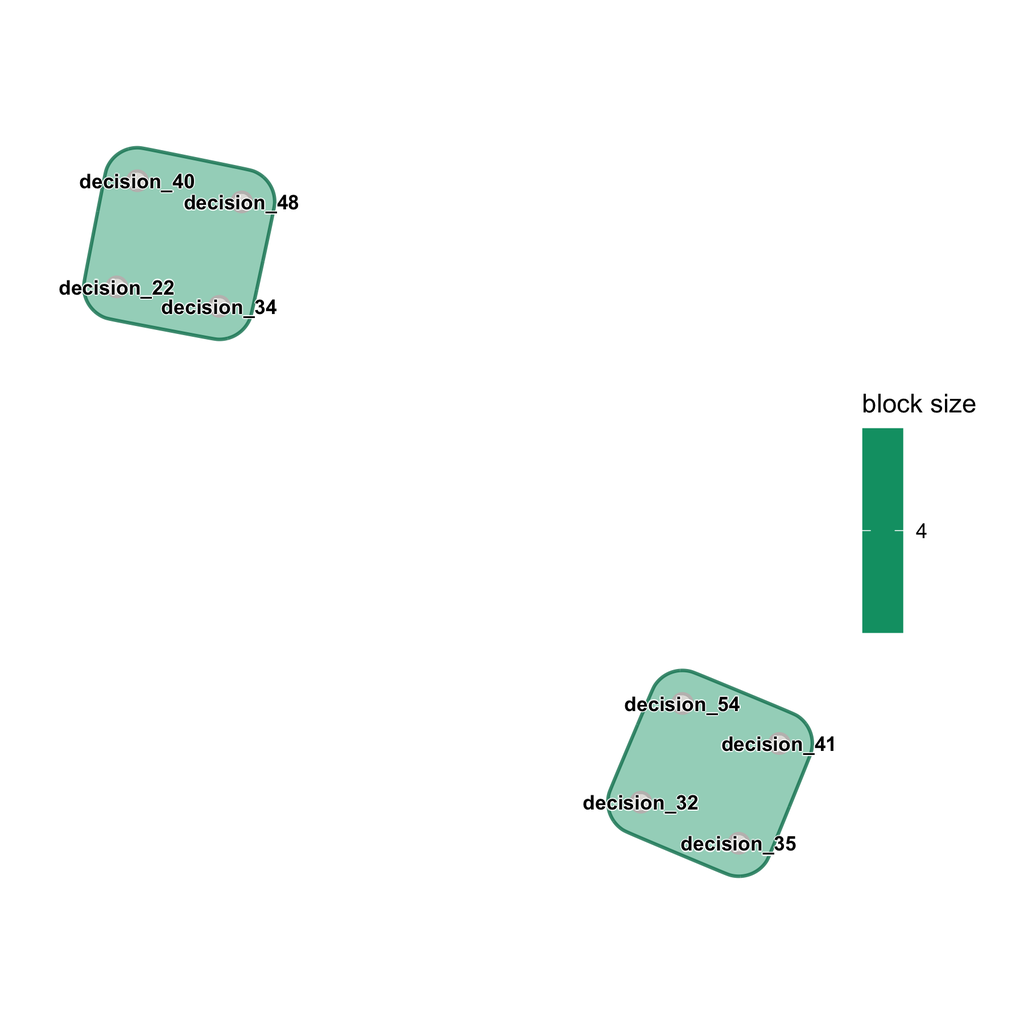

```r
plot(one_decision, color_by = "size", padding = 0.05,
     legend_title = "block size")
```

## Growth

`hg_growth()` counts, at every event time, the nodes and hyperedges present. With `mode = "cumulative"` the counts accumulate and a decision enters at its own date.

```r
growth_blocks <- hg_growth(blocks, mode = "cumulative")
tail(growth_blocks, 3)
```

```
#>    time n_nodes n_edges n_edges_distinct n_memberships
#> 53 5187      58     105              105           296
#> 54 5278      59     107              107           301
#> 55 5369      60     109              109           305
```

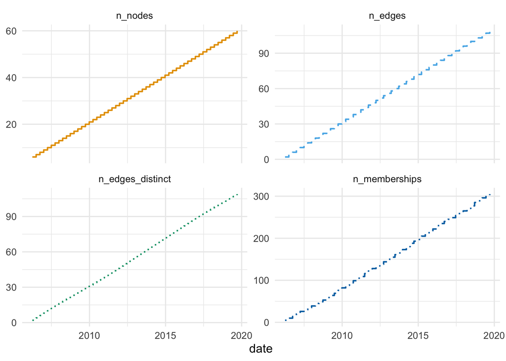

```r
plot(growth_blocks,
     columns = c("n_nodes", "n_edges", "n_edges_distinct", "n_memberships"))
```

`hg_edges()` with `what = "distribution"` gives the distribution of block sizes as the network stood on chosen dates.

```r
census_dates <- as.Date(c("2008-12-31", "2012-12-31", "2016-12-31",
                          "2019-12-31"))
```

```r
sizes_by_date <- hg_edges(blocks, what = "distribution", at = census_dates,
                          snapshot_mode = "cumulative")
head(sizes_by_date)
```

```
#>   time value  n proportion      ccdf
#> 1 1460     1  3  0.1250000 1.0000000
#> 2 1460     2 10  0.4166667 0.8750000
#> 3 1460     3  8  0.3333333 0.4583333
#> 4 1460     4  3  0.1250000 0.1250000
#> 5 2921     1  8  0.1428571 1.0000000
#> 6 2921     2 16  0.2857143 0.8571429
```

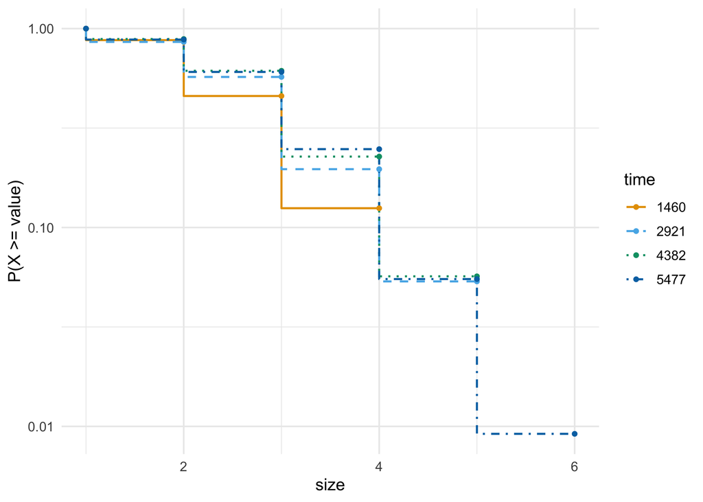

```r
plot(sizes_by_date)
```

The `s` argument counts, for each block, the other blocks sharing at least `s` decisions with it.

```r
intersections <- hg_edges(blocks_all, s = 1:3, what = "distribution",
                          measure = "n_incident_edges")
head(intersections)
```

```
#>   s value n  proportion      ccdf
#> 1 1     0 1 0.009174312 1.0000000
#> 2 1     2 2 0.018348624 0.9908257
#> 3 1     3 2 0.018348624 0.9724771
#> 4 1     4 1 0.009174312 0.9541284
#> 5 1     5 2 0.018348624 0.9449541
#> 6 1     6 3 0.027522936 0.9266055
```

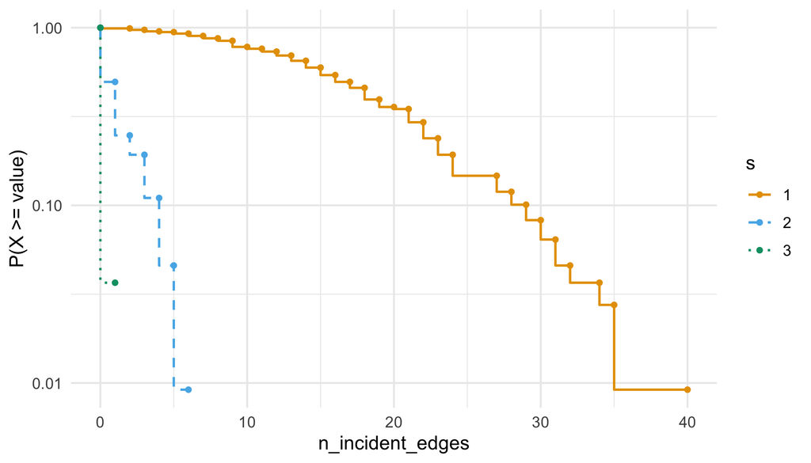

```r
plot(intersections)
```

## Arbitrators and tribunals over time

`hg_measures()` with `what = "distribution"` gives the degree distribution. The `hyperdegree` of an arbitrator is the number of tribunals sat on.

```r
tribunal_counts <- hg_measures(tribunals_all, what = "distribution",
                               measure = "hyperdegree")
tail(tribunal_counts, 3)
```

```
#>   value n proportion       ccdf
#> 7    12 1 0.05555556 0.16666667
#> 8    21 1 0.05555556 0.11111111
#> 9    26 1 0.05555556 0.05555556
```

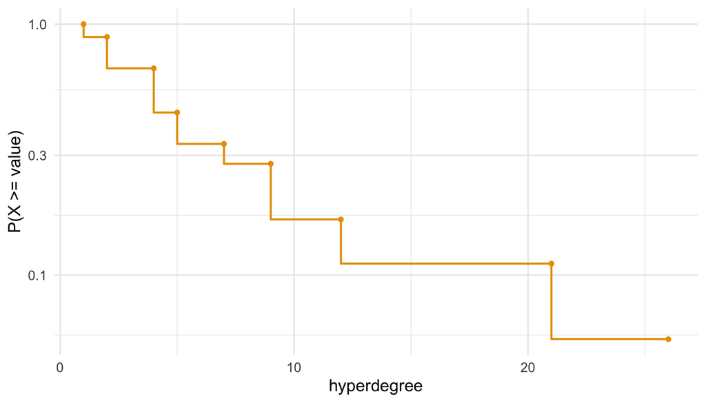

```r
plot(tribunal_counts)
```

For interval data `hg_growth()` reports the active counts and, in the `_cumulative` columns, the counts of a model that never retires a tribunal.

```r
growth_tribunals <- hg_growth(tribunals)
tail(growth_tribunals, 3)
```

```
#>    time n_nodes n_edges n_edges_distinct n_memberships n_nodes_cumulative
#> 70 3547      12       8                8            24                 18
#> 71 3582      12       9                9            27                 18
#> 72 3716      12       9                9            27                 18
#>    n_edges_cumulative n_edges_distinct_cumulative
#> 70                 39                          32
#> 71                 40                          32
#> 72                 40                          32
```

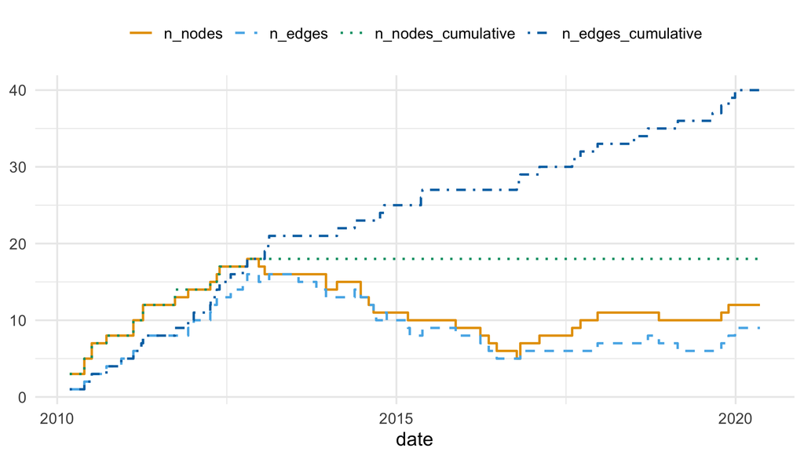

```r
plot(growth_tribunals,
     columns = c("n_nodes", "n_edges", "n_nodes_cumulative", "n_edges_cumulative"),
     facets = FALSE)
```

`hg_edges()` with `what = "summary"` gives, per snapshot, the mean and quartiles of a hyperedge measure; `n_neighbors` is the number of arbitrators within one hop of a tribunal.

```r
neighbourhood <- hg_edges(tribunals, what = "summary", measure = "n_neighbors")
tail(neighbourhood, 3)
```

```
#>    time n_edges     mean       sd min  q25 median q75 max
#> 70 3547       8 5.750000 2.121320   2 5.25    6.5   7   8
#> 71 3582       9 6.111111 1.900292   3 6.00    7.0   7   8
#> 72 3716       9 6.111111 1.900292   3 6.00    7.0   7   8
```

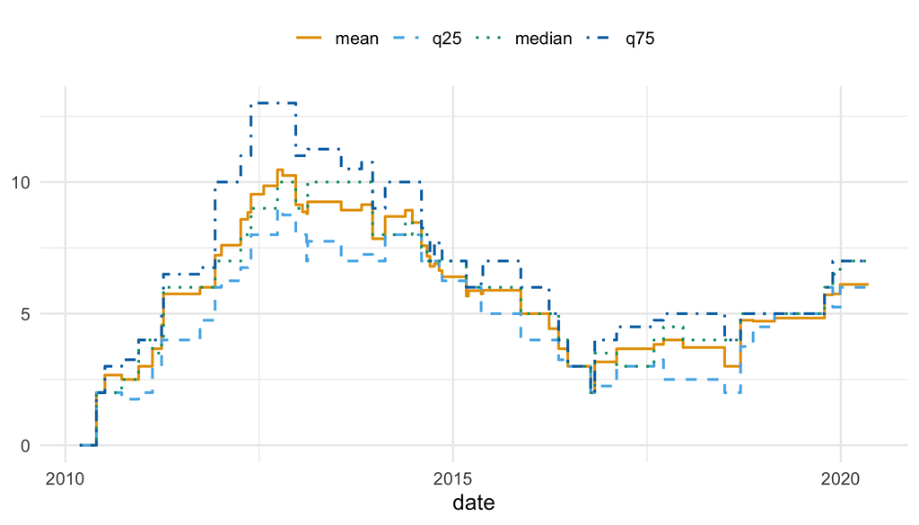

```r
plot(neighbourhood, columns = c("mean", "q25", "median", "q75"), facets = FALSE)
```

`components = TRUE` adds the connectivity of the active hypergraph at each time.

```r
connectivity <- hg_growth(tribunals, components = TRUE)
tail(connectivity, 3)
```

```
#>    time n_nodes n_edges n_edges_distinct n_memberships n_nodes_cumulative
#> 70 3547      12       8                8            24                 18
#> 71 3582      12       9                9            27                 18
#> 72 3716      12       9                9            27                 18
#>    n_edges_cumulative n_edges_distinct_cumulative n_components
#> 70                 39                          32            1
#> 71                 40                          32            1
#> 72                 40                          32            1
#>    largest_component diameter
#> 70                 1        4
#> 71                 1        4
#> 72                 1        4
```

## Repeated collaborations

```r
hg_null_test(tribunals_all, statistic = c("repeated_pairs", "repeated_edges"),
             method = "assignment", n = 199, seed = 1)
```

```
#>        statistic observed null_mean null_lo null_hi          z p_value   n
#> 1 repeated_pairs       64 62.889447      59   67.05  0.4782710   0.705 199
#> 2 repeated_edges        8  8.366834       5   12.00 -0.2204573   1.000 199
#>       method
#> 1 assignment
#> 2 assignment
```

## Hyperedge centralities

The centrality analysis runs on the tribunals active on the last observed date. `multiedges = FALSE` collapses two tribunals with the same three members into one hyperedge.

```r
active <- hypergraph_snapshot(tribunals, at = observation_end,
                              mode = "active", multiedges = FALSE)
active
```

```
#> Hypergraph: 12 nodes, 8 hyperedges
#> Size distribution:
#>   size_3   : 8
#> Source: group membership (member = member, group = edge)
```

`hg_edge_centrality()` builds the s-line graph, in which two tribunals are adjacent when they share at least `s` arbitrators, and ranks the tribunals by betweenness on it. `top = 5` keeps the five most central.

```r
top_betweenness <- hg_edge_centrality(active, s = 1, measure = "betweenness",
                                      top = 5)
top_betweenness
```

```
#>      edge s     measure     value
#> 1 case_35 1 betweenness 0.1190476
#> 2 case_36 1 betweenness 0.1190476
#> 3 case_37 1 betweenness 0.1190476
#> 4 case_40 1 betweenness 0.1190476
#> 5 case_33 1 betweenness 0.0000000
```

`hg_subset()` takes that table and cuts the snapshot down to those cases.

```r
central_tribunals <- hg_subset(active, edges = top_betweenness)
central_tribunals
```

```
#> Hypergraph: 9 nodes, 5 hyperedges
#> Size distribution:
#>   size_3   : 5
#> Source: group membership (member = member, group = edge)
```

`plot()` draws them coloured by sector.

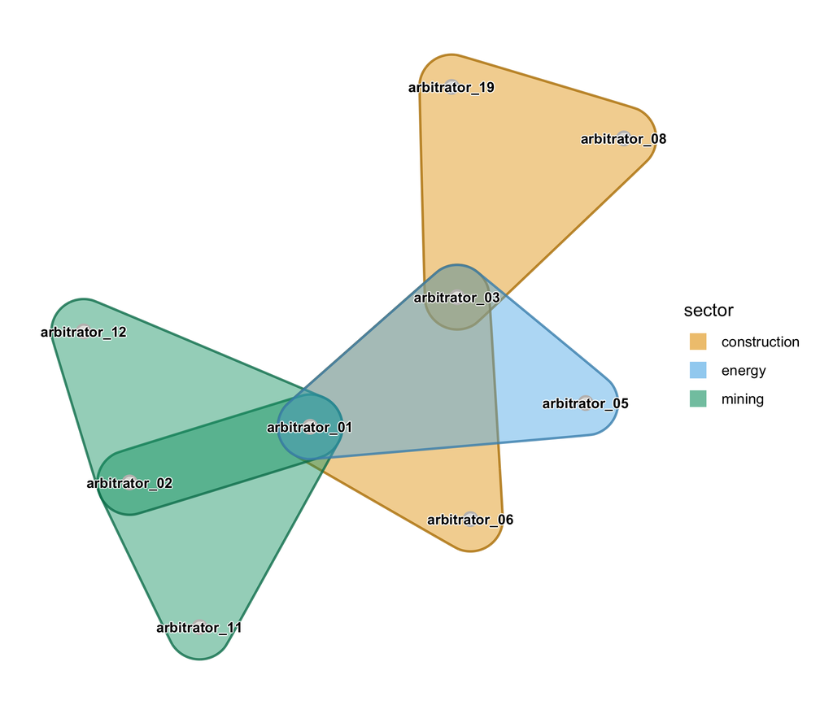

```r
plot(central_tribunals, color_by = "sector", legend_title = "sector",
     label_size = 3)
```

Closeness ranks a different set.

```r
top_closeness <- hg_edge_centrality(active, s = 1, measure = "closeness",
                                    top = 5)
top_closeness
```

```
#>      edge s   measure     value
#> 1 case_35 1 closeness 0.8750000
#> 2 case_36 1 closeness 0.8750000
#> 3 case_37 1 closeness 0.8750000
#> 4 case_40 1 closeness 0.8750000
#> 5 case_34 1 closeness 0.7777778
```

```r
close_tribunals <- hg_subset(active, edges = top_closeness)
```

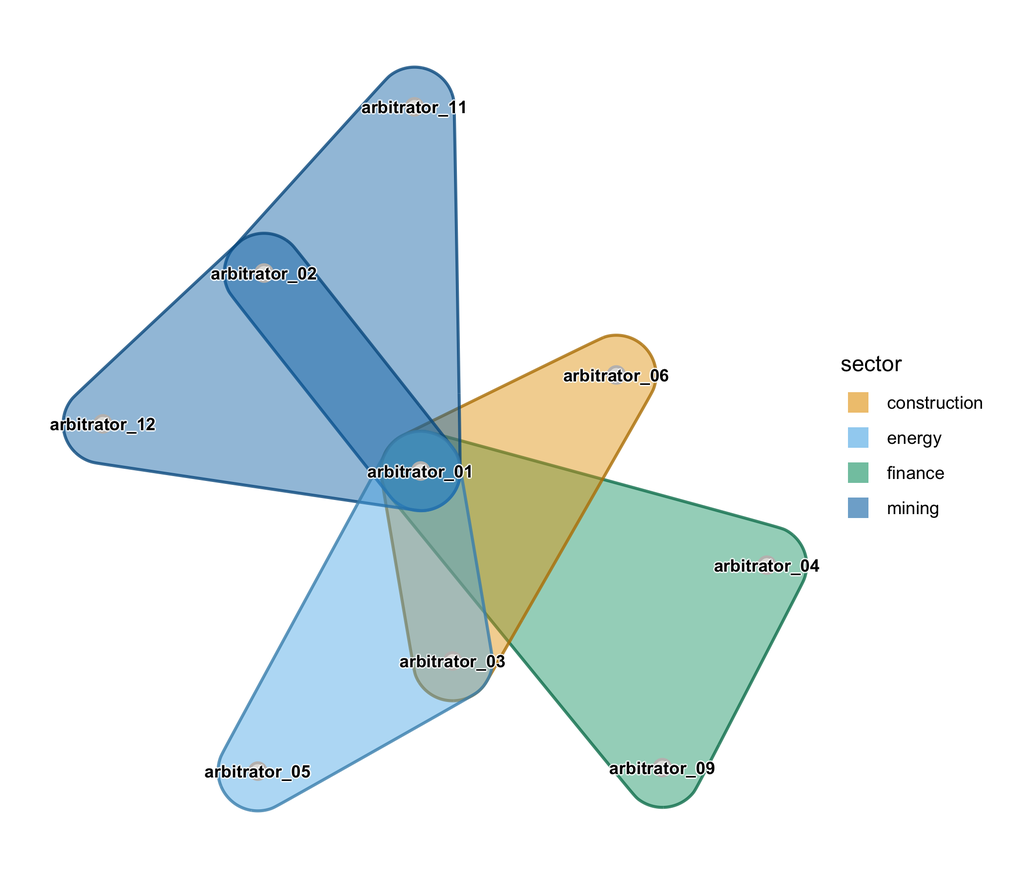

```r
plot(close_tribunals, color_by = "sector", legend_title = "sector",
     label_size = 3)
```

The static aggregate ranks tribunals that never overlapped in time. As for the active snapshot, duplicate trios are collapsed first.

```r
tribunals_binary <- hypergraph_snapshot(tribunals, mode = "cumulative",
                                        multiedges = FALSE)
tribunals_binary
```

```
#> Hypergraph: 18 nodes, 32 hyperedges
#> Size distribution:
#>   size_3   : 32
#> Source: group membership (member = member, group = edge)
```

```r
top_aggregate <- hg_edge_centrality(tribunals_binary, s = 1,
                                    measure = "closeness", top = 5)
top_aggregate
```

```
#>      edge s   measure     value
#> 1 case_07 1 closeness 0.9117647
#> 2 case_13 1 closeness 0.8857143
#> 3 case_24 1 closeness 0.8857143
#> 4 case_27 1 closeness 0.8857143
#> 5 case_35 1 closeness 0.8857143
```

```r
aggregate_tribunals <- hg_subset(tribunals_binary, edges = top_aggregate)
```

`linetype_by` outlines the concluded cases differently from the pending ones.

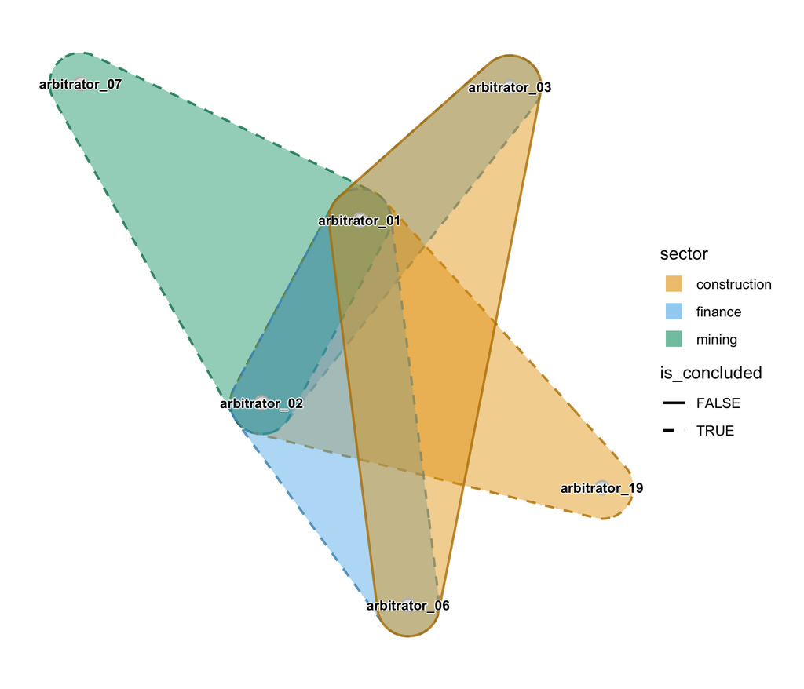

```r
plot(aggregate_tribunals, color_by = "sector", linetype_by = "is_concluded",
     legend_title = "sector", label_size = 3)
```

## Motifs

`hg_motifs()` counts the three four-node motifs of a 3-uniform hypergraph, Y (two of the four possible triples), T (three) and O (all four), against configuration-model nulls that keep degrees and sizes. Random seats give counts close to their null means; the real tribunals show a clear excess.

```r
motifs_aggregate <- hg_motifs(tribunals_all, n = 200, seed = 1)
motifs_aggregate
```

```
#>   motif observed null_mean   null_sd        z   p_value      delta
#> 1     Y       49    41.270 7.1524192 1.080753 0.2985075 0.08199851
#> 2     T        6     3.480 1.6969384 1.485027 0.1592040 0.18694362
#> 3     O        1     0.125 0.3307189 2.645751 0.1293532 0.17073171
#>   normalized_delta   n             method
#> 1        0.3081236 200 configuration_mcmc
#> 2        0.7024730 200 configuration_mcmc
#> 3        0.6415540 200 configuration_mcmc
```

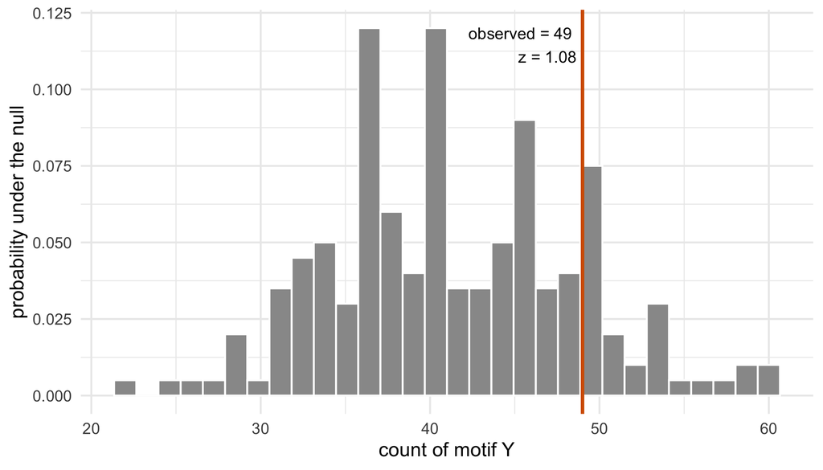

```r
plot(motifs_aggregate)
```

The active snapshot is smaller and has its own census.

```r
motifs_active <- hg_motifs(active, n = 200, seed = 1)
motifs_active
```

```
#>   motif observed null_mean   null_sd          z   p_value      delta
#> 1     Y        5     3.695 1.3160452  0.9916073 0.4129353  0.1027964
#> 2     T        0     0.055 0.2279803 -0.2412490 1.0000000 -0.0135635
#> 3     O        0     0.000 0.0000000         NA 1.0000000  0.0000000
#>   normalized_delta   n             method
#> 1        0.9914073 200 configuration_mcmc
#> 2       -0.1308116 200 configuration_mcmc
#> 3        0.0000000 200 configuration_mcmc
```

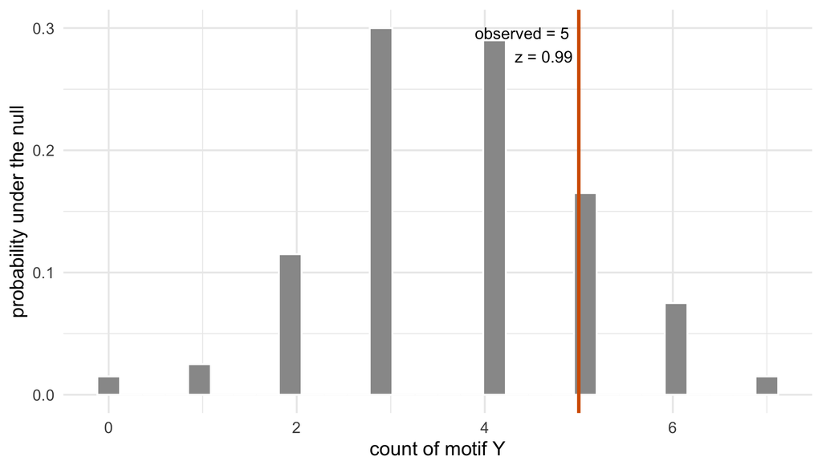

```r
plot(motifs_active)
```

## Communities across representations

The paper clusters the citation data eight ways: the association graph of `hg_project()`, in which a block of size |e| gives each pair of its members the weight 1 / (|e| - 1), on the binary (`bh`) or multi (`mh`) hypergraph, with (`bhs`, `mhs`) or without self-association, the term that joins the citing decision to the decisions it cites; and the citation graph, binary (`bg`) or multi (`mg`), directed or undirected (`bgu`, `mgu`). Our fake decisions only ever cite earlier ones, so every citation is backward already.

`hg_communities()` runs Infomap repeatedly on the chosen projection and keeps the run most similar to all the others as the medoid. The four classic citation graphs first.

```r
communities_bg <- hg_communities(blocks_all, n_runs = 5, trials = 5,
                                 method = "citation", edge_source = "citing",
                                 duplicate_edges = "collapse", directed = TRUE)
communities_bgu <- hg_communities(blocks_all, n_runs = 5, trials = 5,
                                  method = "citation", edge_source = "citing",
                                  duplicate_edges = "collapse")
communities_mg <- hg_communities(blocks_all, n_runs = 5, trials = 5,
                                 method = "citation", edge_source = "citing",
                                 directed = TRUE)
communities_mgu <- hg_communities(blocks_all, n_runs = 5, trials = 5,
                                  method = "citation", edge_source = "citing")
communities_bg
```

```
#> Hypergraph Infomap ensemble: 60 nodes, 5 runs
#> AMI medoid: run 1 (seed 1), 1 communities
```

Then the four association graphs.

```r
communities_bh <- hg_communities(blocks_all, n_runs = 5, trials = 5,
                                 duplicate_edges = "collapse")
communities_bhs <- hg_communities(blocks_all, n_runs = 5, trials = 5,
                                  duplicate_edges = "collapse",
                                  self_association = TRUE, edge_source = "citing")
communities_mh <- hg_communities(blocks_all, n_runs = 5, trials = 5)
communities_mhs <- hg_communities(blocks_all, n_runs = 5, trials = 5,
                                  self_association = TRUE, edge_source = "citing")
communities_mhs
```

```
#> Hypergraph Infomap ensemble: 60 nodes, 5 runs
#> AMI medoid: run 1 (seed 1), 1 communities
```

```r
comparison <- hg_compare_communities(
  bg = communities_bg, bgu = communities_bgu, mg = communities_mg,
  mgu = communities_mgu, bh = communities_bh, bhs = communities_bhs,
  mh = communities_mh, mhs = communities_mhs, hg = blocks_all,
  edge_source = "citing"
)
comparison
```

```
#> Community comparison across 8 representations: bg, bgu, mg, mgu, bh, bhs, mh, mhs
#>  model medoid_seed n_runs n_communities n_singletons n_nontrivial largest
#>     bg           1      5             1            0            1      60
#>    bgu           1      5             1            0            1      60
#>     mg           1      5             1            0            1      60
#>    mgu           1      5             1            0            1      60
#>     bh           1      5             7            5            2      52
#>    bhs           1      5             1            0            1      60
#>     mh           1      5             7            5            2      52
#>    mhs           1      5             1            0            1      60
#>  second    balance
#>      NA         NA
#>      NA         NA
#>      NA         NA
#>      NA         NA
#>       3 0.05769231
#>      NA         NA
#>       3 0.05769231
#>      NA         NA
```

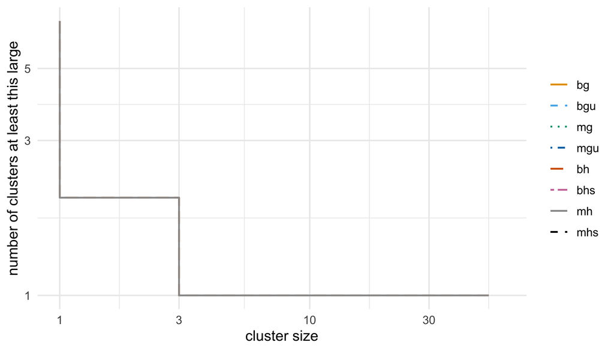

```r
plot(comparison)
```

The similarity table holds the AMI, ARI and NMI between every pair of medoids.

```r
similarity <- as.data.frame(comparison, what = "similarity")
head(similarity)
```

```
#>   model_a model_b n_nodes ami ari nmi
#> 1      bg     bgu      60   1   1   1
#> 2      bg      mg      60   1   1   1
#> 3      bg     mgu      60   1   1   1
#> 4      bg      bh      60   0   0   0
#> 5      bg     bhs      60   1   1   1
#> 6      bg      mh      60   0   0   0
```

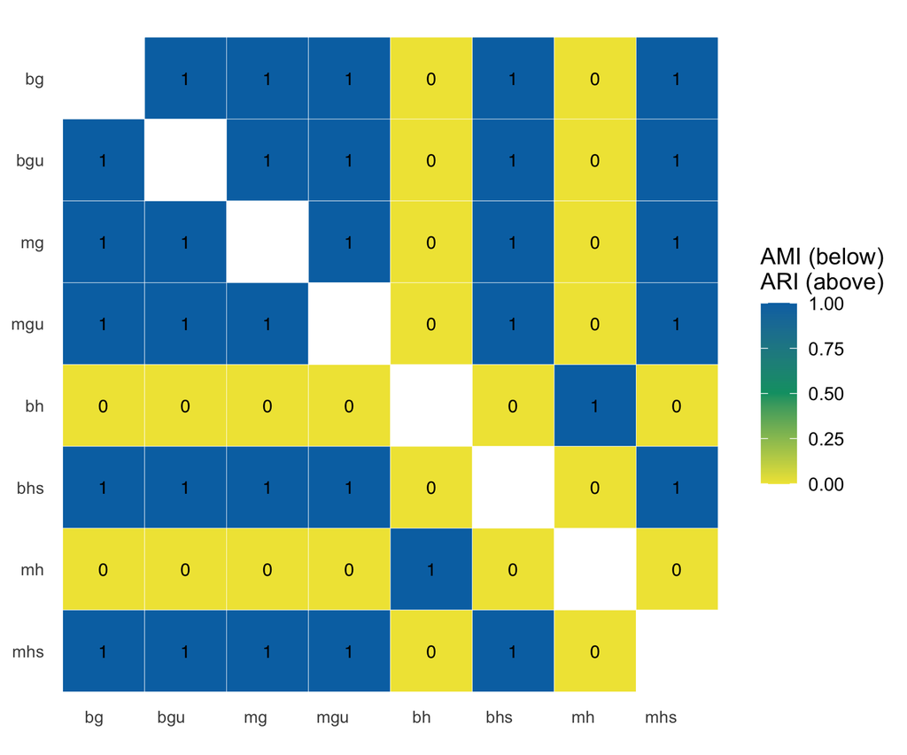

```r
plot(comparison, what = "similarity")
```

The quality table holds coverage, performance, modularity and the worst community conductance of each medoid on its own projection.

```r
quality <- as.data.frame(comparison, what = "quality")
quality
```

```
#>   model  coverage weighted_coverage performance    modularity conductance
#> 1    bg 1.0000000         1.0000000   0.1604520  0.000000e+00          NA
#> 2   bgu 1.0000000         1.0000000   0.1604520  0.000000e+00          NA
#> 3    mg 1.0000000         1.0000000   0.1604520  0.000000e+00          NA
#> 4   mgu 1.0000000         1.0000000   0.1604520  0.000000e+00          NA
#> 5    bh 0.9715302         0.9794521   0.3988701  2.624789e-02   0.4285714
#> 6   bhs 1.0000000         1.0000000   0.2768362 -3.817842e-15          NA
#> 7    mh 0.9715302         0.9794521   0.3988701  2.624789e-02   0.4285714
#> 8   mhs 1.0000000         1.0000000   0.2768362 -3.817842e-15          NA
#>   n_communities
#> 1             1
#> 2             1
#> 3             1
#> 4             1
#> 5             7
#> 6             1
#> 7             7
#> 8             1
```

## What you have seen

Two fake tables, one row per seat and one row per citation, went through the whole workflow of the paper: Table 1 by `summary()`, Table 2 by `hg_representations()`, a decision’s hypergraph by `hg_subset()` and `plot()`, growth and size distributions by `hg_growth()`, `hg_edges()` and `hg_measures()`, repeated collaborations by `hg_null_test()`, hyperedge centralities by `hg_edge_centrality()`, motifs by `hg_motifs()`, and communities by `hg_communities()` and `hg_compare_communities()`. Replace the two tables with your own and nothing else changes. What changes is the answers: made-up data give null results everywhere, which is exactly what the tests are for.

## References

Coupette, C., Hartung, D., and Katz, D. M. (2024). Legal hypergraphs. Philosophical Transactions of the Royal Society A, 382(2270), 20230141.